# AEDV - Lista 1 - Atividade C: Minard

Pedro Henrique Coterli

2023-05-11

Para começar a reproduzir o gráfico de Minard, primeiramente, eu precisei encontrar os dados necessários e baixá-los. Assim, encontrei o seguinte site com as tabelas de que precisaria: [Dados do Minard](https://www.datavis.ca/gallery/re-minard.php). Em seguida, é necessário configurar o caminho do RStudio para que ele consiga encontrar esses arquivos e coletá-los.

```r
setwd(dirname(rstudioapi::getSourceEditorContext()$path))
```

Esse comando faz com que o caminho do RStudio se torne o seu diretório atual. Assim, independentemente do caminho do seu computador, ele possibilitará que os comandos desse arquivo sejam executados no local onde efetivamente estão as tabelas instaladas.

Em seguida, carreguei as bibliotecas necessárias para o projeto.

```r
if(!require(tidyverse)) install.packages("tidyverse", repos = "http://cran.us.r-project.org")
if(!require(lubridate)) install.packages("lubridate", repos = "http://cran.us.r-project.org")
if(!require(ggrepel)) install.packages("ggrepel", repos = "http://cran.us.r-project.org")
if(!require(gridExtra)) install.packages("gridExtra", repos = "http://cran.us.r-project.org")
if(!require(RColorBrewer)) install.packages("RColorBrewer", repos = "http://cran.us.r-project.org")
if(!require(ggthemes)) install.packages("ggthemes", repos = "http://cran.us.r-project.org")
library(tidyverse)
library(lubridate)
library(ggrepel)
library(gridExtra)
library(RColorBrewer)
library(ggthemes)
```

Após isso, carreguei os dados das tabelas baixadas para dentro de variáveis para que pudesse trabalhar com elas.

```r
cidades = read.table("Minard/cities.txt", header = T, stringsAsFactors = F)
tropas = read.table("Minard/troops.txt", header = T, stringsAsFactors = F)
temperaturas = read.table("Minard/temps.txt", header = T, stringsAsFactors = F) %>%
  mutate(dmy(date))
```

A seguir, comecei a construção do gráfico das tropas. Para isso, comecei gerando um gráfico de caminho com o eixo x sendo a longitude, o y sendo a latitude, a cor sendo a direção (avanço ou recuo), a largura da linha sendo a quantidade de sobreviventes e com as bordas dos trechos arredondadas para um melhor encaixe visual.

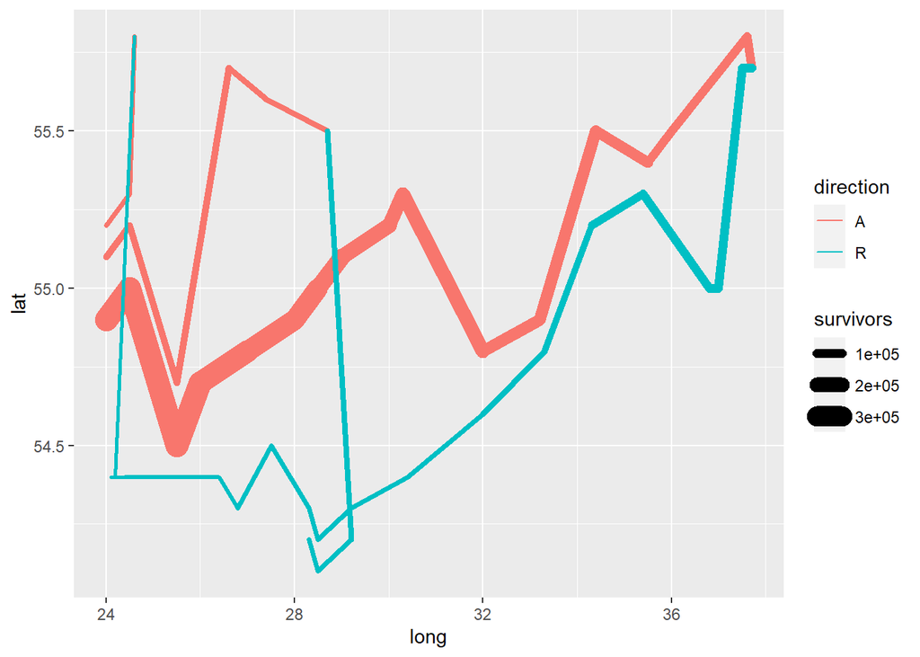

```r
graf_tropas = ggplot() +
  geom_path(data = tropas, aes(x = long, y = lat, group = group, color = direction, linewidth = survivors), lineend = "round")

graf_tropas
```

Logo após, inseri pontos representando as cidades do mapa com seus respectivos nomes.

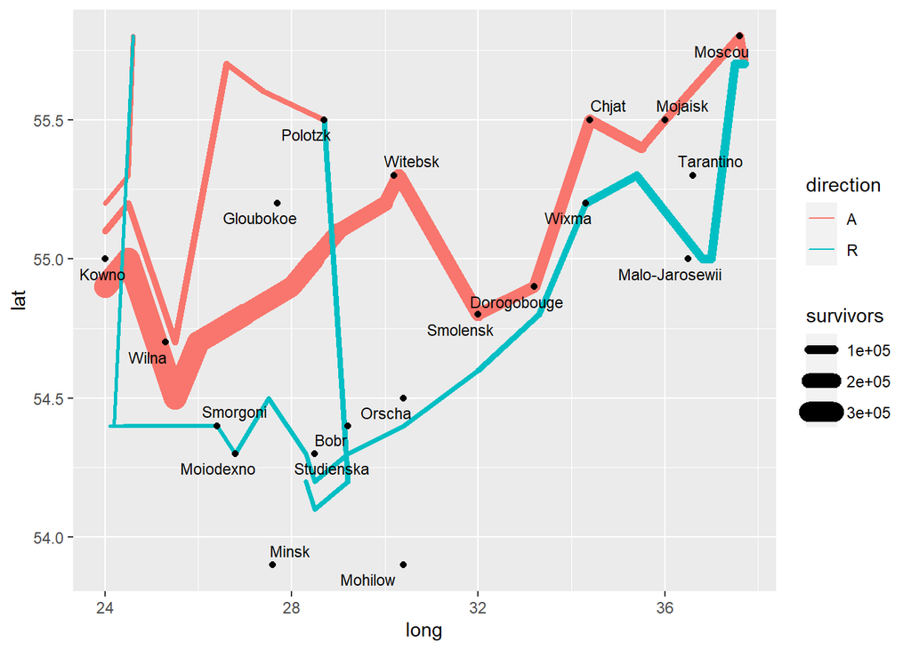

```r
graf_tropas = graf_tropas +
  geom_point(data = cidades, aes(x = long, y = lat)) +
  geom_text_repel(data = cidades, aes(x = long, y = lat, label = city), size = 3)

graf_tropas
```

Em seguida, aumentei o tamanho das linhas para uma maior expressividade e apaguei as legendas de cor e de largura da linha.

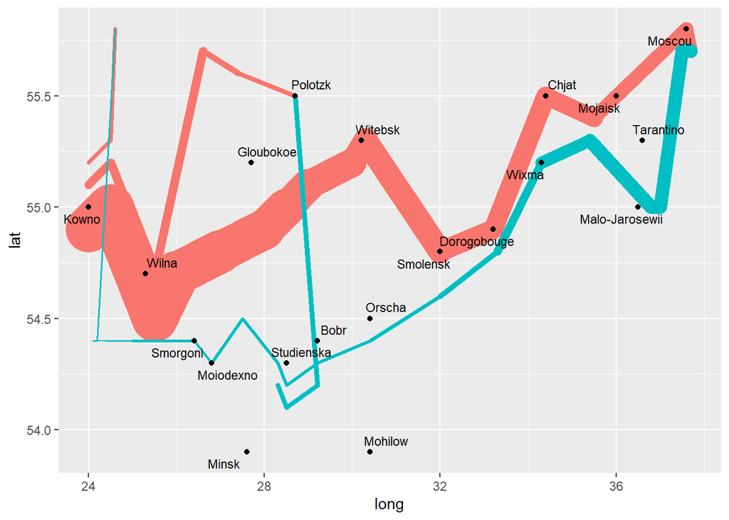

```r
graf_tropas = graf_tropas +
  scale_linewidth(range = c(0.5, 15)) +
  guides(color = F, linewidth = F)

graf_tropas
```

Por fim, personalizei o gráfico, ajustando os textos, as cores e os temas.

```r
graf_tropas = graf_tropas +
  scale_color_brewer(palette = "Pastel1") +
  theme_light() +
  labs(x = NULL, y = "Latitude (º)", title = "A Trama de Minard de 1812") +
  theme(plot.title = element_text(hjust = 0.5, size = 25), axis.text.x = element_blank(), axis.ticks.x = element_blank())
```

E o resultado final do primeiro gráfico foi este:

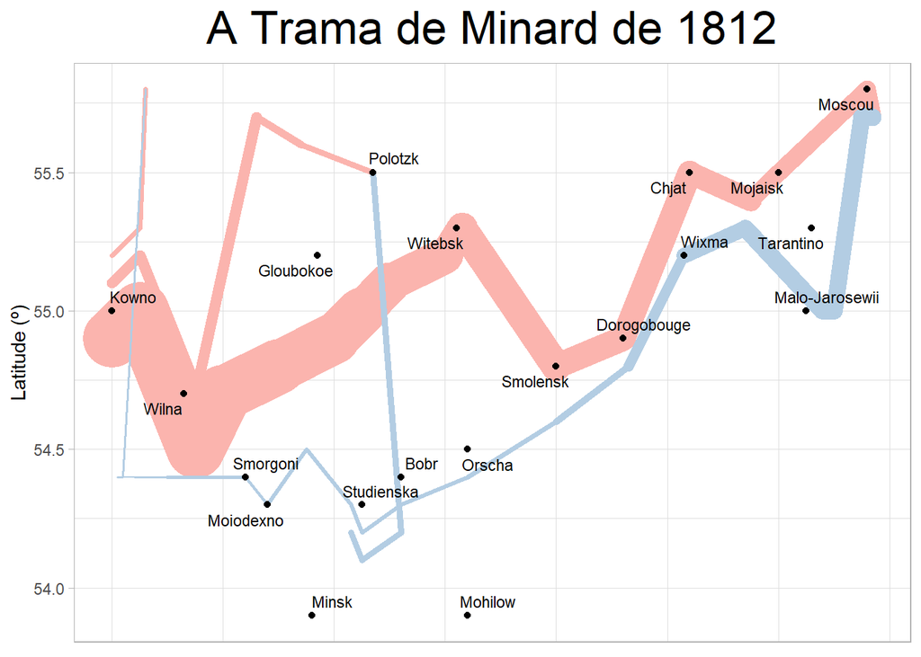

```r
graf_tropas
```

A seguir, comecei a fazer o gráfico das temperaturas. Para isso, primeiramente, criei novos rótulos para a tabela de temperaturas de forma que eles informassem a temperatura e a data correspondente.

```r
temperaturas_ajustadas = temperaturas %>% mutate(rotulos = paste0(temp, "º , ", month, ". ", day))
```

Depois, iniciei efetivamente o gráfico gerando um gráfico de linha com o eixo x representando a longitude e o eixo y representando a temperatura no recuo das tropas.

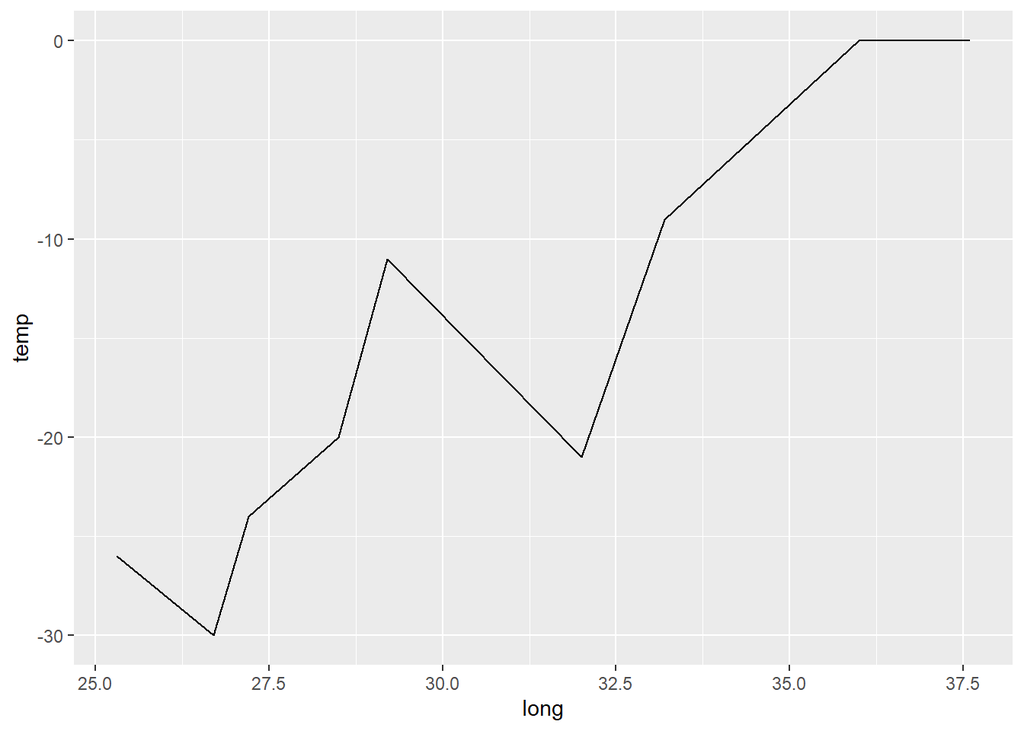

```r
graf_temperaturas = ggplot(temperaturas_ajustadas, aes(x = long, y = temp)) +
  geom_line()

graf_temperaturas
```

Em seguida, adicionei os rótulos criados anteriormente.

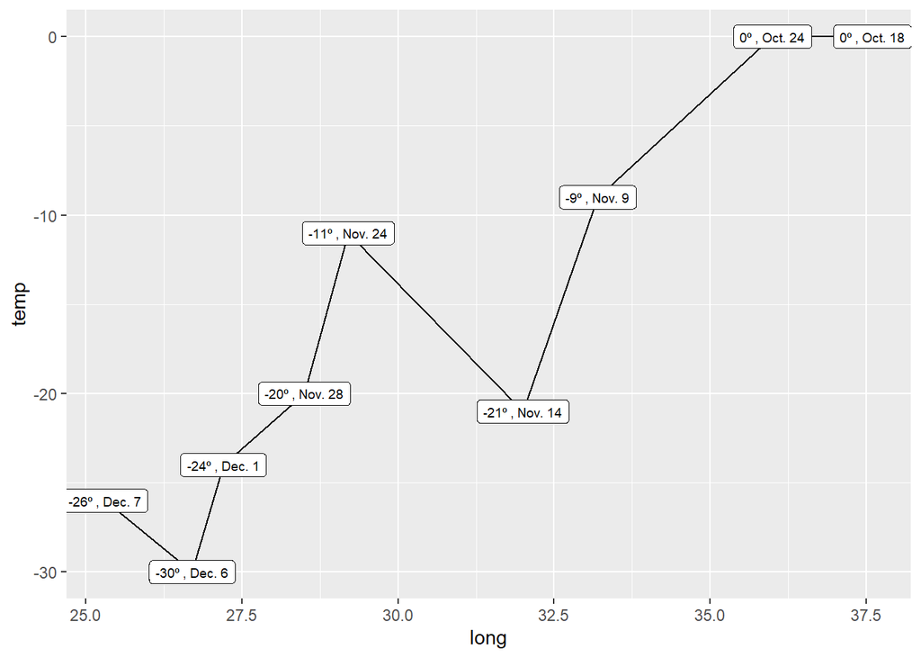

```r
graf_temperaturas = graf_temperaturas +
  geom_label(aes(label = rotulos), size = 2.5)

graf_temperaturas
```

Após isso, configurei os eixos e ajustei as escalas de modo a obter um melhor encaixe com o primeiro gráfico, o que será feito daqui a pouco.

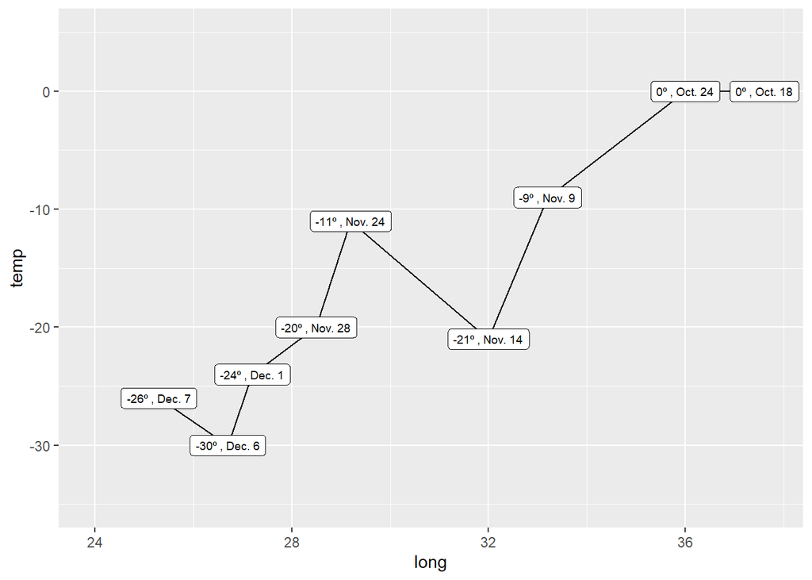

```r
graf_temperaturas = graf_temperaturas +
  scale_x_continuous() +
  scale_y_continuous(position = "left") +
  coord_cartesian(ylim = c(-35, 5), xlim = c(23.95, 37.7))

graf_temperaturas
```

Para finalizar, personalizei novamente os textos e os temas.

```r
graf_temperaturas = graf_temperaturas +
  labs(x = "Longitude (º)", y = "Temperatura na recuada (ºC)") +
  theme(panel.grid.major.x = element_blank(),
        panel.grid.minor.x = element_blank(),
        panel.grid.minor.y = element_blank(),
        axis.text.x = element_blank(),
        axis.ticks = element_blank(),
        panel.border = element_blank()) +
  theme_light()
```

Abaixo está o resultado final do segundo gráfico.

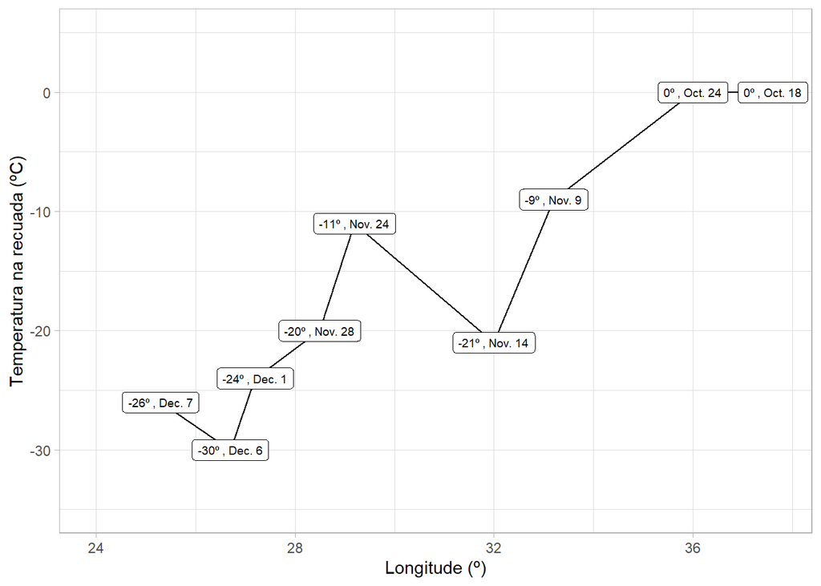

```r
graf_temperaturas
```

Por fim, bastava unir os dois gráficos em uma única imagem.

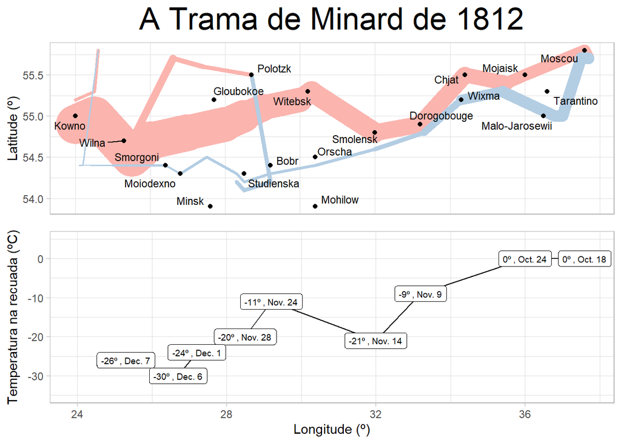

```r
ambos = rbind(ggplotGrob(graf_tropas), ggplotGrob(graf_temperaturas))

grid::grid.newpage()
grid::grid.draw(ambos)
```

E essa foi a minha recriação da trama de Minard!